Bacterial Genome Sequencing Results

# Summary

## B9TF7H_2

#### 2026-06-25

**Your sample was not able to be assembled.**

Your genome was not able to assemble likely because not enough reads were obtained. Please check the FAQ for detailed information.

#### **Statistics**

| Total bp sequenced | 91,641,178 bp |
| --- | --- |
| Total number of reads | 10,746 reads |

**Raw reads are contained within the accompanying folders.**

# **Reads**

**Plot of all reads**

- Each **dot** on the graph represents a single read, plotted by its length and its mean [Phred quality score](https://en.wikipedia.org/wiki/Phred_quality_score).
- The histograms along the top and right show the distribution of read lengths and Phred scores, respectively.
- `median phred` line shows the median Phred score of all of the reads used in the assembly.
- **rN50** is the “reads N50”, which is defined as the shortest read that covers 50% of the total number of bases in the reads used for assembly. [This](https://www.molecularecologist.com/2017/03/29/whats-n50/) is a good reference for better understanding N50, though note that we are reporting rN50 which uses reads instead of contigs.

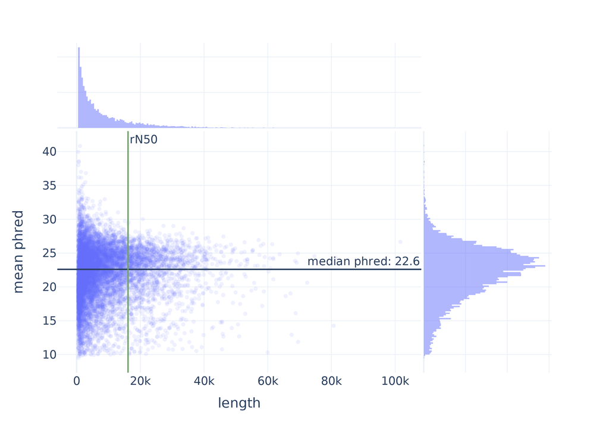

**What does rN50 mean?**

- Your rN50 is **16,138 bp**
- This is an assembly statistic that helps assess read quality.
- **rN50** is the “reads N50”, which is defined as the shortest read that covers 50% of the total number of bases in the reads used for assembly. [This](https://www.molecularecologist.com/2017/03/29/whats-n50/) is a good reference for better understanding N50, though note that we are reporting rN50 which uses reads instead of contigs.

# FAQ

### What does it mean that my genome sequencing `failed`?

- Sequencing `failure` is defined as:
  - A high-quality assembly was not able to generated from your data
  - And the raw data target of 210 Mb (standard Bacteria service) or 360 Mb (Big Bacteria service) was not achieved
- The raw sequencing reads (`.fastq` files) are including in the associated files
- You may also still receive some of the other file types depending on at what stage your sample failed

### Why did my genome sequencing fail?

- Although we cannot provide definitive reasons on why each specific sample had poor data yield, the most common reasons include:
  - Your sample was not shipped at the [required DNA concentration of 50 ng/µL](https://www.plasmidsaurus.com/bac_learn_more/#step3)
    - DNA quantification via Nanodrop is unreliable
    - Qubit (or equivalent fluorometric assay) is strongly recommended
  - Your sample was [not from a bacterial isolate](https://www.plasmidsaurus.com/faq/#mixture-bact)
  - Your sample contains [fragmented/degraded gDNA](https://www.plasmidsaurus.com/bac_learn_more/#step3) – samples should be handled with utmost care, including:
    - Pipette with wide-bore tips
    - Minimize freeze/thaw cycles
    - Do not expose to extreme temperature/pH
    - Do not expose to UV radiation
    - Do not use intercalating dyes
    - Do not over-dry DNA pellet
    - Do not vortex
  - Your sample contains inhibitors, such as:
    - RNA
    - Detergents (SDS, Triton-X100, etc.)
    - Denaturants (guanidinium salts, phenol, etc.)
    - Residual contaminants from the organism/tissue (heme, humic acid, polyphenols, polysaccharides, lipids, etc.)
    - Insoluble, colored, or cloudy material
    - Other inhibitors (EDTA, etc.)
- To prevent future failures, please adhere closely to our [sample prep guidelines](https://www.plasmidsaurus.com/bac_learn_more/#sample_prep_bac)

### What happens now?

- If this is your first failure report, we will:
  1. Perform QC on your sample
  2. Adjust the prep protocol (e.g. clean up the sample, alter the prep input, etc.)
  3. Repeat the sequencing at no additional charge
  4. Combine the data from the two runs together to increase chances of a successful assembly
- If the sample does not produce an assembly on the second attempt, we determine that your sample is not sequenceable, very likely due to one or more of the reasons listed above

### How is the assembly generated?

1. Remove the bottom 5% worst fastq reads via Filtlong v0.2.1 (default parameters)
2. Downsample the reads to 250 Mb via Filtlong to create a rough sketch of the assembly with [Miniasm](https://academic.oup.com/bioinformatics/article/32/14/2103/1742895) v0.3
3. Using information acquired from the Miniasm assembly, re-downsample the reads to ~100x coverage (do nothing if there isn’t at least 100x coverage) with heavy weight applied to removing low quality reads (helps small plasmids stick around)
4. Run a [Flye](https://www.nature.com/articles/s41587-019-0072-8) v2.9.1 assembly with parameters selected for high quality ONT reads
5. Polish Flye assembly via [Medaka](https://github.com/nanoporetech/medaka) v1.8.0 using the reads generated in step 3
6. Run several analyses:
   - annotation
     - [Bakta](https://www.microbiologyresearch.org/content/journal/mgen/10.1099/mgen.0.000685) v1.11
   - contig analysis
     - [Bandage](https://academic.oup.com/bioinformatics/article/31/20/3350/196114) v0.8.1
   - genome completeness and contamination
     - [CheckM](https://genome.cshlp.org/content/25/7/1043) v1.2.2
   - species / plasmid identification
     - [Mash](https://genomebiology.biomedcentral.com/articles/10.1186/s13059-019-1841-x) v2.3 against RefSeq genomes+plasmids
     - [Sourmash](https://joss.theoj.org/papers/10.21105/joss.00027) v4.6.1 against GenBank
     - [CheckM](https://genome.cshlp.org/content/25/7/1043) v1.2.2